Summer Institute 2026 · Day 3

# Agentic AI: From Chatbots to Agents

Models that don't just answer — they plan, use tools, and work in a loop until the job is done. Plus how to direct them safely.

D. Alex Quistberg, PhD, MPH · Associate Research Professor  
An Introduction to AI for Urban Health Research & Practice

Overview

### Today's Lecture

What makes something an "agent," how to steer it with context, how it connects to tools, and how to keep it reliable.

Part 1

What Is an Agent?

Chatbot vs. agent, the agent loop, and types of agents.

Part 2

Context Engineering

Managing the model's finite context — lessons from real agent builders.

Part 3

MCP, Tools & Loops

MCP, tools, loops, multi-agent patterns, and agent configuration.

Part 4

Tools & Using Agents Well

The current tool landscape, computer use agents, evaluation, and guardrails for sensitive work.

Objectives

### Learning Objectives

- Distinguish an AI agent from a chatbot, and describe the agent loop and architecture.
- Apply context-engineering principles to design effective agent interactions.
- Explain the Model Context Protocol (MCP) and how tools extend a model.
- Configure agents with Skills (SKILL.md) and instruction files (CLAUDE.md).
- Use repeatable "loops" with clear stop conditions to get reliable results.
- Describe multi-agent patterns and when to use them.
- Evaluate agents and set guardrails appropriate for sensitive urban-health work.

Part 1

## What Is an Agent?

An agent is a language model that can use tools in a loop until it completes a task.

Definition

### Chatbot vs. Agent

#### Chatbot

- Single-turn question and answer
- Stateless between messages
- You drive every step
- Generates text — can't act

#### Agent

- Plans and reasons about a goal
- Keeps state across many steps
- Acts: runs code, reads/writes files, calls tools
- Works toward completion with minimal hand-holding

"An agent is an LLM that can use tools in a loop until it completes a task." — the working definition we'll use all day.

Source: ["Beyond Vibes: How to Actually Evaluate AI Agents,"](https://medium.com/data-analytics-at-nesta/how-to-evaluate-ai-agents-from-ground-truth-to-llm-as-judge-part-1-426de60f4710) Nesta (2025)

Core idea

### The Agent Loop

Each turn: the model picks an action, the action runs in an environment (a sandbox), the result is appended to context, and the loop continues.

Source: [Anthropic, "Building Effective Agents" (2024)](https://www.anthropic.com/research/building-effective-agents)

Varieties

### Types of Agents

#### Coding

Write, run, and debug code; build apps; analyze data programmatically.

#### Research

Search the web, synthesize many sources, produce cited reports.

#### Workflow

Create documents, manage files, run multi-step office tasks.

#### Computer-use

Control mouse/keyboard, navigate apps and websites like a person.

The boundaries blur — most capable tools now do several of these.

Adapted from [OpenAI, "A Practical Guide to Building Agents" (2025)](https://cdn.openai.com/business-guides-and-resources/a-practical-guide-to-building-agents.pdf)

Architecture

### The Five Components of an Agent System

Backbone Model → Planning → Tool Interface → Memory → Sandbox

#### What ties them together

An orchestration harness (the agent loop from slide 5) coordinates all five components: the model reasons, the planner sequences steps, tools execute, memory preserves state, and the sandbox keeps execution safe.

#### Why it matters

When something goes wrong, one of these five is usually the culprit. Diagnosing agent failures means asking: did the model misunderstand? did the plan go off-track? did a tool fail? did context get lost? did the sandbox block something?

Adapted from OpenAI, ["A Practical Guide to Building Agents"](https://cdn.openai.com/business-guides-and-resources/a-practical-guide-to-building-agents.pdf) (2025)

Part 2

## Context Engineering

Prompting was about words. Building agents is about curating the whole information environment the model sees.

The shift

### From Prompt to Context Engineering

As work moves from one-shot chats to agents running over many turns, the question changes from "what do I *say*?" to "what *configuration of context* makes the right behavior likely?"

#### Prompt engineering

Writing one good instruction — wording and phrasing for a single response.

#### Context engineering

Curating the full set of tokens the model sees over time: instructions + tools + retrieved data + history + memory.

Context is a finite resource — every token competes for the model's attention.

Source: ["Effective context engineering for AI agents,"](https://www.anthropic.com/engineering/effective-context-engineering-for-ai-agents) Anthropic (Sep 2025)

Anatomy

### What's in the Context Window

#### System instructions

Role, rules, output format, boundaries.

#### Tools

What actions are available and how to call them.

#### Retrieved data

Relevant files, documents, prior analyses (RAG).

#### History & memory

Earlier turns; durable notes that persist across steps.

#### User input

The actual request, with examples and constraints.

#### Manage it

Compact, summarize, and prune — long context degrades and costs more.

Managing this state well is most of what separates a flaky demo from a reliable agent.

Source: ["Effective context engineering for AI agents," Anthropic (2025)](https://www.anthropic.com/engineering/effective-context-engineering-for-ai-agents)

From the field

### Lessons from Building Real Agents

#### Build on models, don't train them

Betting on context engineering (not fine-tuning a custom model) let the team ship in hours, not weeks — and stay "the boat on the rising tide," improving as models improve.

#### It's an experimental science

They rebuilt their agent framework four times. Cost & latency hinge on keeping the context stable (cache-friendly). Expect iteration, not a clean recipe.

Practical takeaway: keep instructions stable, append rather than rewrite, and design context for reuse.

Source: ["Context Engineering for AI Agents: Lessons from Building Manus"](https://manus.im/blog/Context-Engineering-for-AI-Agents-Lessons-from-Building-Manus) (2025)

Part 3

## Tools, MCP & Loops

How agents reach your data and tools, how to configure and loop them, and when to use more than one.

In practice

### Chat vs. Cowork

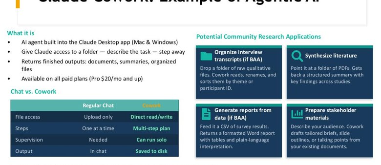

Regular chat vs. an agent like Cowork — file access, multi-step autonomy, and where output lands (from my CRP workshop).

- Chat uploads files and answers one step at a time, with you supervising.
- Cowork reads/writes a folder, plans multiple steps, and saves finished files to disk.
- Same model underneath — the difference is autonomy and tool access.

Tool use

### How Tool Use Works

model decides  
a tool would help

→

emits a tool call  
{name, arguments}

→

your app runs it

→

result back to model

Tools let a text model do what it otherwise can't: browse the web, run code, query a database, call an API, read your files.

This is the "act" step of the agent loop — and the reason agents can affect the real world.

Source: [Anthropic, "Tool use with Claude" (docs)](https://docs.anthropic.com/en/docs/build-with-claude/tool-use/overview)

Standard

### The Model Context Protocol (MCP)

[figure not shown]

#### What it is

- An open standard (from Anthropic) for connecting models to tools and data
- Now broadly adopted across the major providers
- A large ecosystem of ready-made "servers"

#### Why it matters

- One connector instead of custom glue per tool
- Reuse it across different models and apps
- Connect an agent to your databases, files, services

You've used this already: the connectors in tools like Cowork are MCP servers.

Diagram adapted from Anthropic's MCP documentation · modelcontextprotocol.io

Architecture

### How MCP Connects Things

Model

↔

MCP client  
(the app)

↔

MCP server  
(the connector)

↔

your tool / data  
DB · files · API

A request flows model → client → server → tool, and the result flows back along the same chain.

Examples: query a database, search files, call a web API, read a spreadsheet — all through one standard interface.

Source: [Model Context Protocol — modelcontextprotocol.io](https://modelcontextprotocol.io)

Skills

### Agent Skills: Teaching the Agent Your Way

A **Skill** is a reusable folder of expertise. If MCP is how an agent reaches tools, a Skill is how it knows *your* way of doing a task.

#### What's in it

- `SKILL.md` — name + description + instructions
- `scripts/` — code it can run (optional)
- `references/` — docs loaded on demand

#### Why it helps

- Write your method once, reuse it everywhere
- Loads only when the task matches the description
- Portable across claude.ai, Claude Code, and Cowork

Build one fast with the **Skill Creator** (built into Claude Desktop & Cowork). Public-health ideas: a de-identification checklist, a plain-language rewriter, a grant Specific-Aims formatter.

Anthropic, "Equipping agents for the real world with Agent Skills" (2026) · [code.claude.com/docs/skills](https://code.claude.com/docs/en/skills)

Configuration

### Configuring Agent Behavior

#### CLAUDE.md files

A Markdown file in your project root that the agent reads on every launch. Use it for: persistent instructions ('always use Python 3.12'), project conventions ('we use snake_case'), domain context ('this repo handles HIPAA data'), and recurring reminders ('run tests before committing'). Claude Code and Cowork read these automatically.

#### System prompts

For API-based agents and tools like Google AI Studio: the system prompt is the equivalent — persistent instructions the model sees before every user message. Same purpose, different delivery mechanism. Think of it as the agent's standing orders.

The more specific and domain-aware your configuration, the less you need to repeat yourself — and the fewer mistakes the agent makes.

Source: [Anthropic, Claude Code documentation](https://docs.anthropic.com/en/docs/claude-code)

Reliability

### Loops: Repeatable Workflows That Know When to Stop

A "loop" is a reusable instruction that tells an agent what to do, how to check its work, and when to stop — turning a one-off prompt into a dependable routine.

#### Docs sweep

Review the codebase, update stale docs, verify, open a pull request.

Stop: docs match the code.

#### Refactor until happy

Refactor, live-test, auto-review, and commit after each step.

Stop: architecture is satisfactory & checks pass.

#### Optimize to a target

Keep optimizing and re-measuring under the same test.

Stop: page loads under 50 ms.

Every good loop names an explicit VERIFY / STOP condition — otherwise an agent runs forever or stops too early.

Source: Forward Future ["Loop Library"](https://signals.forwardfuture.ai/loop-library/) — repeatable agent workflows

Philosophy

### Build the Loop, Not the Agent

'You are not building an agent. You are building the loop that rebuilds it.' — Forward Future (2025)

#### Fund the iteration

The artifact (the report, the code, the analysis) is a side effect. The durable asset is the loop that produces it: plan → execute → evaluate → iterate. Invest in making the loop fast and cheap to run.

#### Expect to rebuild

Models change, tools change, requirements change. An agent built around a brittle, one-time prompt will break. A loop with explicit evaluation criteria can adapt — swap the model, swap the tools, keep the loop.

#### Evaluation is the loop

Without a way to judge whether the output is good enough, there is no loop — just a one-shot generation. The VERIFY step is what closes the circle.

Adapted from Forward Future, ["Build the Loop, Not the Agent"](https://signals.forwardfuture.ai/loop-library/) (2025)

Advanced

### Multi-Agent Systems

When a task is too complex for one agent, split it across several — each with its own tools, instructions, and expertise.

#### Manager

One 'boss' agent delegates to specialist sub-agents, reviews their work, and synthesizes the final output. Example: a lead analyst that calls a data agent, a writing agent, and a fact-checker.

#### Sequential

Agents hand off to each other in a chain. Agent A finishes, passes output to Agent B, and so on. Example: extract → clean → analyze → report.

#### Parallel

Multiple agents work on different parts simultaneously. A coordinator merges results. Example: three agents each reviewing a different section of a grant.

#### Decentralized

Agents communicate peer-to-peer with no central coordinator. Google's A2A (Agent-to-Agent) protocol targets this pattern — still early.

Start with a single agent. Add agents only when you can clearly articulate what each one does that the others cannot.

Adapted from OpenAI, ["A Practical Guide to Building Agents"](https://cdn.openai.com/business-guides-and-resources/a-practical-guide-to-building-agents.pdf) (2025)

Part 4

## Tools & Using Agents Well

What to reach for today, computer use agents, how to know it actually works, and how to stay safe with sensitive data.

Landscape

### The Agentic Tools Landscape

| Tool | Surface | Coding needed? | Best for |
| --- | --- | --- | --- |
| Claude Cowork | Desktop app | No | Files, documents, research — for non-developers |
| Claude Code | Terminal | Terminal | Reasoning-heavy, multi-file coding & analysis |
| Codex CLI (OpenAI) | Terminal / editor / cloud | Terminal | Fast coding agent; tops coding benchmarks |
| Antigravity (Gemini CLI) | Terminal / IDE | Terminal | Free, very large context; Gemini CLI folded into Antigravity |
| Cursor | Code editor | Editor | Agent mode inside an AI-native editor |

Also free/open: OpenCode, Cline, Goose, Aider. Specific rankings shift monthly — pick by surface and workflow, not the leaderboard.

Rankings: [Terminal-Bench (terminal-bench.ai)](https://www.terminal-bench.ai) · accessed June 2026

Landscape

### Agentic Harnesses Compared

The same idea — a model plus tools running in a loop — ships in different surfaces and autonomy levels (recall the three ways to work with AI from Day 1).

| Harness | What it is | Best for |
| --- | --- | --- |
| **Claude Code** | Terminal agent (Anthropic) | Coding, data, file automation in a repo |
| **Cowork** | Desktop agent (Anthropic) | Non-coders: files, connectors, Skills, scheduled tasks |
| **Codex** | Terminal agent (OpenAI) | Long, “walk-away” autonomous runs |
| **Antigravity** | Agent-first IDE + CLI (Google) | Orchestrating multiple agents; browser-tested builds |
| **OpenCoworker** | Open-source desktop agent | Privacy-sensitive work; bring-your-own / local model |

Choose on: **surface** (terminal / desktop / IDE), **autonomy**, **model lock-in**, and **data control**. For sensitive health data, weight model choice and local execution heavily.

Rankings: [Terminal-Bench (terminal-bench.ai)](https://www.terminal-bench.ai)

Emerging

### Computer Use Agents

Agents that control a mouse and keyboard — navigating apps and websites the way a human would.

#### Claude Computer Use

Anthropic's approach: the model sees screenshots and emits mouse/keyboard actions. Available in Claude Desktop (Cowork) and via API. Can navigate any app — not just browsers.

#### OpenAI Operator

OpenAI's browser agent (CUA — Computer-Using Agent). Navigates web apps, fills forms, completes multi-step web tasks. Currently browser-only.

#### Google Mariner

Google's browser agent built on Gemini. Chrome extension that can navigate and interact with web pages. Research preview.

These are early-stage but evolving fast. Main use cases: automating repetitive UI tasks, accessibility, and connecting to tools that have no API. Always supervise — they click real buttons.

Source: [Anthropic, "Introducing computer use" (2024)](https://www.anthropic.com/news/3-5-models-and-computer-use)

Research

### How People Actually Work with Agents

#### The split

Anthropic studied thousands of real Claude Code sessions and found a consistent pattern:

- 70% of planning decisions — made by humans
- 80% of code execution — done by the agent
- Domain expertise matters more than coding skill
- 9 distinct work modes identified (from quick lookups to deep architecture)

#### What this means for you

You don't need to be a programmer to direct a coding agent effectively. The bottleneck is knowing what to build, not how to build it. Public health domain expertise — understanding your data, your workflows, your constraints — is more valuable than coding proficiency when working with these tools.

Source: [Anthropic, "Agentic coding and persistent returns to expertise" (2026)](https://www.anthropic.com/research/claude-code-expertise)

Evaluation

### Beyond Vibes: Does the Agent Actually Work?

An agent that shines in a demo can fail "in the wild." Reliability needs real evaluation, not impressions.

#### Ground truth

Work out the correct answers by hand, then compare the agent's output to them.

#### LLM-as-judge

Use a model to grade outputs at scale — calibrated against your ground truth.

#### Test repeatedly

Run many cases; track where and how it fails, not just whether one demo worked.

Especially important when wrong answers have real consequences — health guidance, resource allocation, policy.

Source: ["Beyond Vibes: How to Actually Evaluate AI Agents,"](https://medium.com/data-analytics-at-nesta/how-to-evaluate-ai-agents-from-ground-truth-to-llm-as-judge-part-1-426de60f4710) Nesta (2025)

Safety

### Guardrails for Agentic Work

#### Human in the loop

Approve consequential or irreversible actions.

#### Least privilege

Give only the access the task needs; sandbox execution.

#### Verify outputs

Check facts, code, and numbers before acting on them.

#### Protect data

Keep protected health data out of tools that aren't approved for it.

Agents act in the world — so the stakes of a mistake are higher than with a chatbot. Scope and supervise accordingly.

Source: [OpenAI, "A Practical Guide to Building Agents" — guardrails (2025)](https://cdn.openai.com/business-guides-and-resources/a-practical-guide-to-building-agents.pdf)

Verification

### Verification Is the Bottleneck

Agents can generate far faster than you can check. As output gets cheaper, *your* verification becomes the limiting step — and the real skill.

#### Why it matters

- Fluent output is not the same as correct output.
- The faster the agent, the more there is to check.
- The higher the stakes, the higher your burden of proof.

#### Turn the model on its own work

- Make it an *adversarial reader*: "Argue why this analysis is wrong."
- Ask it to find the weakest claim, the missing control, the unchecked assumption.
- Have it critique your code, your draft, your study design — then you decide.

Using AI to pressure-test your own thinking is one of its most reliable uses — and it keeps you in the loop.

Framing adapted from Beam & Aslim, ["Thinking With Agents"](https://thinkingwithagents.github.io/) (Univ. of Vermont, 2026) · thinkingwithagents.github.io

Applied

### Agents for Urban Health

#### Research agent

Sweep the literature on a hazard, synthesize, and draft a cited brief — then you verify.

#### Data agent

Clean a dataset, run the analysis, generate figures and reproducible code.

#### Admin agent

Cut administrative time — e.g., Nesta's agents helping low-carbon-tech installers.

Same rules apply: define a clear loop with a stop condition, evaluate it, and keep a human on consequential decisions.

Recent: [LLM-driven multi-agent simulation for epidemic–economic dynamics (Information, 2026)](https://www.mdpi.com/2078-2489/17/3/259)

Hands-on

### Today's Activities

#### 1 · Context engineering exercise (20 min)

Build a reusable system prompt / project context for a recurring task.

#### 2 · Claude Code / Cowork walkthrough (25 min)

Watch an agent read files, run code, and produce a deliverable.

#### 3 · Loops, Skills & Orchestration (30 min)

Build a loop with VERIFY/STOP conditions, write a SKILL.md, and orchestrate a multi-step workflow.

#### 4 · Local AI with Ollama (20 min)

Run models on your own machine — private and free. When local is enough vs. when you need cloud.

Activities 4 and 5 from the previous version — Google AI Studio agent building and AI for grant writing — have been moved to Day 4.

Recap

## What to Take Away

An agent is a model using tools in a loop. You steer it with context, connect it with MCP, make it reliable with explicit loops and evaluation, and keep a human on the consequential calls. Tomorrow: putting these capabilities to work across urban-health workflows.